# Reproducible Research: Peer Assessment 1

Alberto A. Caeiro Jr

## This project is part of the Data Science Specialization from Johns Hopkins University, offered by Coursera.

### Setting Working Folder

```r
setwd('/Users/acaeiro/Developer/Data Science Specialization/RepData_PeerAssessment1')
```

### Loading and preprocessing the data

The dataset is zipped, so we have to unzip it and then load into R.

```r
zipFile <- "./activity.zip"
fileList <- unzip(zipFile)
activity <- read.csv(fileList[1], sep=",", header=TRUE)
```

The date column needs to be reformatted to DATE format.

```r
activity$date <- as.Date(activity$date, format="%Y-%m-%d")
str(activity)
```

```
## 'data.frame':    17568 obs. of  3 variables:
##  $ steps   : int  NA NA NA NA NA NA NA NA NA NA ...
##  $ date    : Date, format: "2012-10-01" "2012-10-01" ...
##  $ interval: int  0 5 10 15 20 25 30 35 40 45 ...
```

## What is mean total number of steps taken per day?

1. Total numbers of steps taken Each Day (Hist)

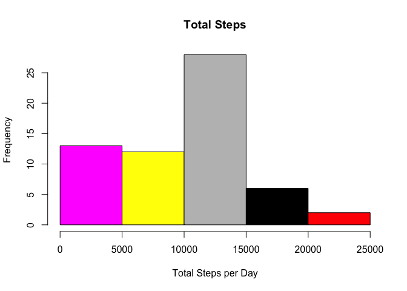

```r
byValue=list(Date = activity$date)
SumOfSteps <- aggregate(activity$steps, by=byValue, FUN=sum, na.rm=TRUE)
names(SumOfSteps) <- c("Date", "Sum.Of.Steps")
with(SumOfSteps, hist(Sum.Of.Steps, col=Date, xlab="Total Steps per Day", main="Total Steps"))
```

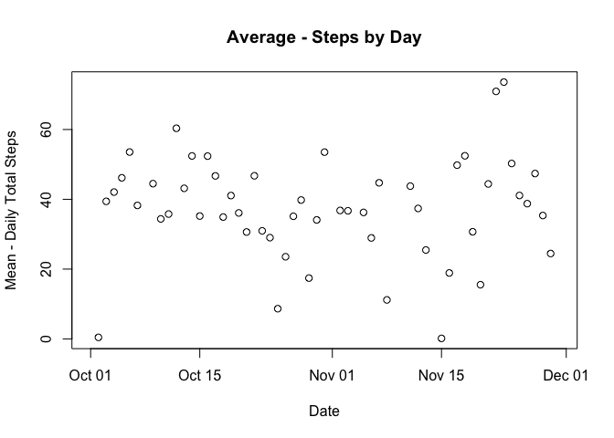

```r
byValue=list(Date = activity$date)
meanOfSteps <- aggregate(activity$steps, by=byValue, FUN=mean, na.rm=TRUE)
names(meanOfSteps) <- c("Date", "Average.Of.Steps")
with(meanOfSteps, plot(Date, Average.Of.Steps, ylab="Mean - Daily Total Steps",
                       main="Average - Steps by Day"))
```

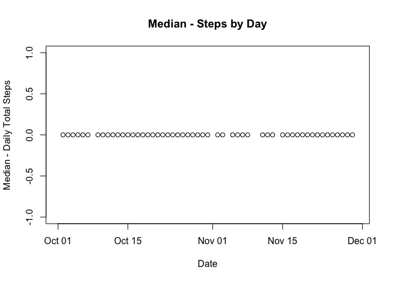

```r
byValue=list(Date = activity$date)
medianOfSteps <- aggregate(activity$steps, by=byValue, FUN=median, na.rm=TRUE)
names(medianOfSteps) <- c("Date", "Median.Of.Steps")
with(medianOfSteps, plot(Date, Median.Of.Steps, ylab="Median - Daily Total Steps",
                               main="Median - Steps by Day"))
```

## What is the average daily activity pattern?

4. Make a time series plot (i.e. type = “l”) of the 5-minute interval (x-axis) and the average number of steps taken, averaged across all days (y-axis)

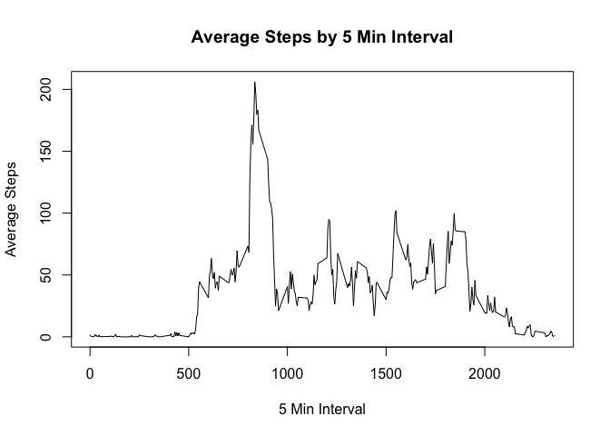

```r
byValue=list(TimeInterval = activity$interval)
stepsByInterval <- aggregate(activity$steps, by=byValue, FUN=mean, na.rm=TRUE)
names(stepsByInterval) <- c("Interval", "Mean.Of.Steps")
with(stepsByInterval, plot(Interval, Mean.Of.Steps, type="l", xlab="5 Min Interval", ylab="Average Steps",
                               main="Average Steps by 5 Min Interval"))
```

5. Which 5-minute interval, on average across all the days in the dataset, contains the maximum number of steps?

```r
t <- cbind(stepsByInterval$Mean.Of.Steps, stepsByInterval$Interval)
colnames(t) <- c("Mean Of Steps", "5 min Interval")
maxNumOfSteps <- max(t[,1])
intervalOfMaxSteps <- t[(t[,1] == maxNumOfSteps),][2]
print(intervalOfMaxSteps)
```

```
## 5 min Interval
##            835
```

## Imputing missing values

6. Counting and Reporting the number of NA in the dataset

```r
sum(is.na(activity$steps))
```

```
## [1] 2304
```

and it represents in % of the sampling…

```r
mean(is.na(activity$steps))
```

```
## [1] 0.1311
```

7. The strategy for filling in missing values will be to use the mean of the day. In case of the mean == NaN, 0 will be used instead. In case of a missing value in the day (but with the mean =>0), the missing value will be replaced by the mean of the day. Here you can find the mean of steps by day.

```r
print(meanOfSteps)
```

```
##          Date Average.Of.Steps
## 1  2012-10-01              NaN
## 2  2012-10-02           0.4375
## 3  2012-10-03          39.4167
## 4  2012-10-04          42.0694
## 5  2012-10-05          46.1597
## 6  2012-10-06          53.5417
## 7  2012-10-07          38.2465
## 8  2012-10-08              NaN
## 9  2012-10-09          44.4826
## 10 2012-10-10          34.3750
## 11 2012-10-11          35.7778
## 12 2012-10-12          60.3542
## 13 2012-10-13          43.1458
## 14 2012-10-14          52.4236
```

[output cut: 47 more lines]

8. Create a new dataset that is equal to the original dataset but with the missing data filled in. So with the strategy stated above we have:

```r
t <- activity
for (i in 1:length(meanOfSteps$Date)){
    if (is.nan(meanOfSteps$Average.Of.Steps[i])) t[t[,2]==meanOfSteps$Date[i],1] <- 0
}
complDataset <- t
```

Considering this new dataset, let’s re-check itens 1, 2 and 3 to see what are the changes.

Looking at Total Steps.

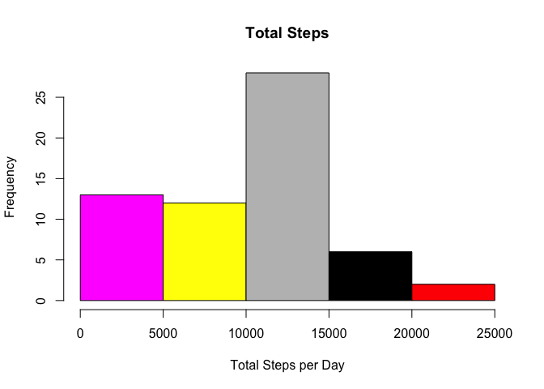

```r
byValue=list(Date = complDataset$date)
SumOfStepsComplete <- aggregate(complDataset$steps, by=byValue, FUN=sum, na.rm=TRUE)
names(SumOfStepsComplete) <- c("Date", "Sum.Of.Steps")
with(SumOfStepsComplete, hist(Sum.Of.Steps, col=Date, xlab="Total Steps per Day", main="Total Steps"))
```

Average Steps

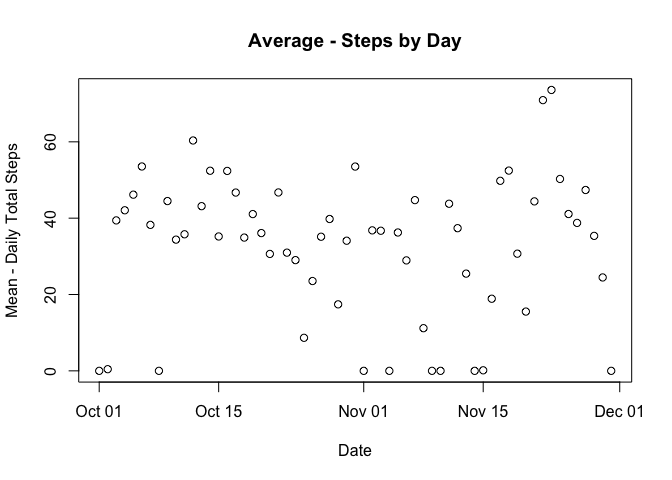

```r
byValue=list(Date = complDataset$date)
meanOfStepsComplete <- aggregate(complDataset$steps, by=byValue, FUN=mean, na.rm=TRUE)
names(meanOfStepsComplete) <- c("Date", "Average.Of.Steps")
with(meanOfStepsComplete, plot(Date, Average.Of.Steps, ylab="Mean - Daily Total Steps",
                       main="Average - Steps by Day"))
```

Median

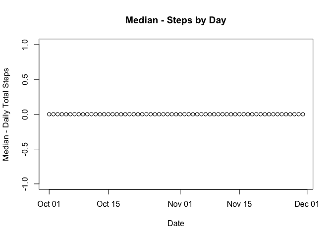

```r
byValue=list(Date = complDataset$date)
medianOfStepsComplete <- aggregate(complDataset$steps, by=byValue, FUN=median, na.rm=TRUE)
names(medianOfStepsComplete) <- c("Date", "Median.Of.Steps")
with(medianOfStepsComplete, plot(Date, Median.Of.Steps, ylab="Median - Daily Total Steps",
                               main="Median - Steps by Day"))
```

# What happens when imputing missing values.

For better anwser this, we can see both graphs (on each metric - sum, mean, median) side by side. Total Sum

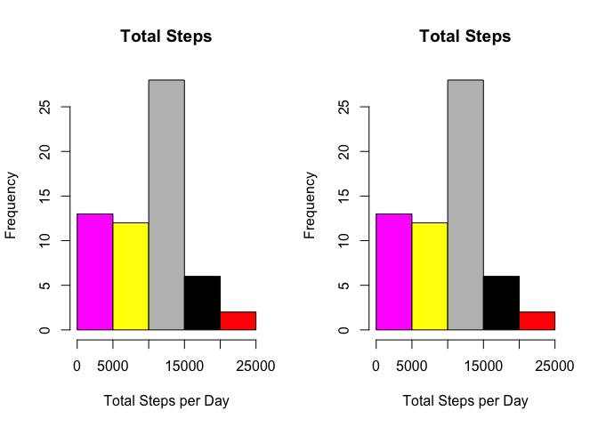

```r
par(mfrow=c(1, 2))
with(SumOfSteps, hist(Sum.Of.Steps, col=Date, xlab="Total Steps per Day", main="Total Steps"))
with(SumOfStepsComplete, hist(Sum.Of.Steps, col=Date, xlab="Total Steps per Day", main="Total Steps"))
```

Mean

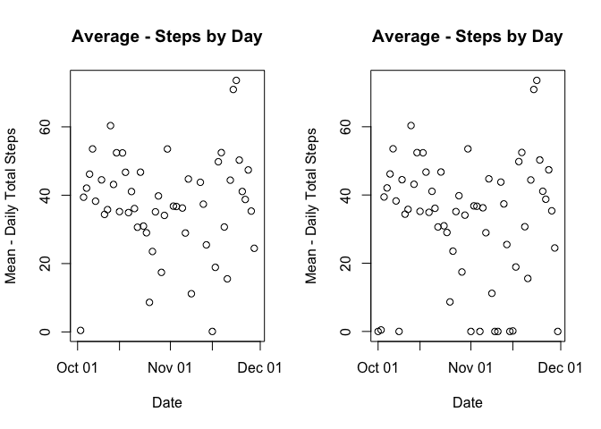

```r
par(mfrow=c(1, 2))
with(meanOfSteps, plot(Date, Average.Of.Steps, ylab="Mean - Daily Total Steps",
                       main="Average - Steps by Day"))
with(meanOfStepsComplete, plot(Date, Average.Of.Steps, ylab="Mean - Daily Total Steps",
                       main="Average - Steps by Day"))
```

Median

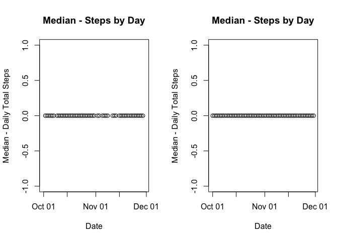

```r
par(mfrow=c(1, 2))
with(medianOfSteps, plot(Date, Median.Of.Steps, ylab="Median - Daily Total Steps",
                               main="Median - Steps by Day"))
with(medianOfStepsComplete, plot(Date, Median.Of.Steps, ylab="Median - Daily Total Steps",
                               main="Median - Steps by Day"))
```

## Are there differences in activity patterns between weekdays and weekends?

Creating a new variable for holding info about weekdays/weekends.

```r
complDataset$weekday <- factor(weekdays(complDataset$date), levels=c("weekday", "weekend"))
for (i in 1:length(complDataset$date)){
    if (weekdays(complDataset$date[i]) %in% c("Saturday", "Sunday")) {
        complDataset$weekday[i] <- "weekend"
    } else {
        complDataset$weekday[i] <- "weekday"
    }
}
```

Checking if there are any difference in activity patterns between weekdays and weekends. Make a panel plot containing a time series plot (i.e. type = “l”) of the 5-minute interval (x-axis) and the average number of steps taken, averaged across all weekday days or weekend days (y-axis).

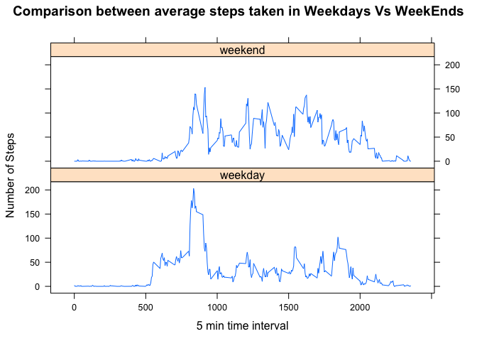

```r
complDatasetWeekDay <- subset(complDataset, weekday == "weekday", c(interval, steps))
byValue=list(TimeInterval = complDatasetWeekDay$interval)
avgStepsByIntervalWD <- aggregate(complDatasetWeekDay$steps, by=byValue, FUN=mean, na.rm=TRUE)
avgStepsByIntervalWD$weekday <- c("weekday")
complDatasetWeekEnd <- subset(complDataset, weekday == "weekend", c(interval, steps))
byValue=list(TimeInterval = complDatasetWeekEnd$interval)
avgStepsByIntervalWE <- aggregate(complDatasetWeekEnd$steps, by=byValue, FUN=mean, na.rm=TRUE)
avgStepsByIntervalWE$weekday <- c("weekend")
avgStepsGrouped <- rbind(avgStepsByIntervalWD, avgStepsByIntervalWE)

names(avgStepsGrouped) <- c("TimeInterval", "AvgSteps", "Weekdate")

library(lattice)
avgStepsGrouped <- transform(avgStepsGrouped, Weekdate = factor(Weekdate))
xyplot(AvgSteps ~ TimeInterval | Weekdate, data = avgStepsGrouped, type="l", layout=c(1,2),
       ylab="Number of Steps", xlab="5 min time interval",
       main="Comparison between average steps taken in Weekdays Vs WeekEnds")
```